```r
library(MTS)
library(lmtest)
library(vars)
```

```r
data <- read.csv("2021.csv", header = T, sep=",")
head(data)
```

|  | date | bitcoin | bcash | biance | little | tesla | tsmc | amd | qualcom |
| --- | --- | --- | --- | --- | --- | --- | --- | --- | --- |
| 1 | 6/22/2020 | 9648.718 | 239.7897 | 16.47529 | 44.18800 | 198.864 | 56.00 | 54.76 | 89.13 |
| 2 | 6/23/2020 | 9629.658 | 240.8085 | 16.42257 | 44.17928 | 200.356 | 56.76 | 53.99 | 89.35 |
| 3 | 6/24/2020 | 9313.610 | 233.1558 | 16.02676 | 42.84383 | 192.170 | 56.58 | 52.39 | 89.14 |
| 4 | 6/25/2020 | 9264.813 | 232.4136 | 15.92271 | 42.56353 | 197.196 | 57.04 | 51.93 | 88.96 |
| 5 | 6/26/2020 | 9162.918 | 230.1077 | 15.74922 | 43.32079 | 191.948 | 56.33 | 50.10 | 88.02 |
| 6 | 6/29/2020 | 9190.854 | 225.1970 | 15.50523 | 41.85103 | 201.870 | 56.39 | 50.28 | 89.01 |

### Visualización de los datos

```r
##  [1] "#00008B" "#46008B" "#8B008B" "#8B0046" "#8B0000" "#8B4500" "#8B8B00"
##  [8] "#468B00" "#008B00" "#008B45" "#008B8B" "#00468B"
tiempo <- seq(1:nrow(data))/248+2020.5
par(mfrow=c(2,4))
plot(tiempo,data[,2], ylab = "Bitcoin", xlab="Tiempo", type="l", col = "#00008B")
plot(tiempo,data[,3], ylab = "B.Cash", xlab="Tiempo", type="l", col = "#46008B")
```

```r
plot(tiempo,data[,4], ylab = "Biance", xlab="Tiempo", type="l", col = "#8B008B")
plot(tiempo,data[,5], ylab = "Little", xlab="Tiempo", type="l", col = "#8B0046")
```

```r
plot(tiempo,data[,6], ylab = "Tesla", xlab="Tiempo", type="l", col = "#8B4500")
plot(tiempo,data[,7], ylab = "TSMC", xlab="Tiempo", type="l", col = "#8B8B00")
```

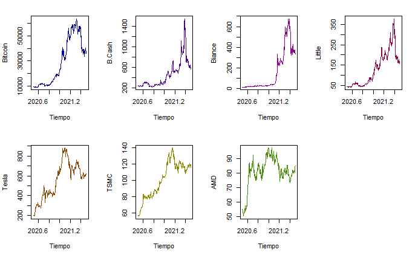

```r
plot(tiempo,data[,8], ylab = "AMD", xlab="Tiempo", type="l", col = "#468B00")
plot(tiempo,data[,9], ylab = "Qualcom", xlab="Tiempo", type="l", col = "#008B00")
```

### Diferenciación de los datos

```r
### Se transforman las series a estacionarias

#d_est <- as.data.frame(lapply(data[,-1],log))
#d_est <- as.data.frame(lapply(d_est,diff))
d_est <- as.data.frame(lapply(data[,-1],diff))
head(d_est)
```

|  | bitcoin | bcash | biance | little | tesla | tsmc | amd | qualcom |
| --- | --- | --- | --- | --- | --- | --- | --- | --- |
| 1 | -19.05957 | 1.018768 | -0.052721 | -0.008725 | 1.492005 | 0.759998 | -0.769996 | 0.220001 |
| 2 | -316.04785 | -7.652664 | -0.395809 | -1.335453 | -8.186005 | -0.179996 | -1.600003 | -0.209999 |
| 3 | -48.79688 | -0.742172 | -0.104049 | -0.280296 | 5.026001 | 0.459999 | -0.459999 | -0.180000 |
| 4 | -101.89551 | -2.305923 | -0.173485 | 0.757256 | -5.248001 | -0.709999 | -1.830002 | -0.940002 |
| 5 | 27.93652 | -4.910676 | -0.243992 | -1.469754 | 9.921997 | 0.059997 | 0.180001 | 0.990005 |
| 6 | -52.86133 | -3.205337 | -0.091650 | -0.383239 | 14.092011 | 0.380001 | 2.330002 | 2.199997 |

```r
NA
```

```r
#Se visualizan las series en su forma estacionaria.
tiempo <- seq(1:nrow(d_est))/247+2020.5
par(mfrow=c(2,4))
plot(tiempo,d_est[,1], ylab = "Bitcoin", xlab="Tiempo", type="l", col = "#00008B")
plot(tiempo,d_est[,2], ylab = "B.Cash", xlab="Tiempo", type="l", col = "#46008B")
```

```r
plot(tiempo,d_est[,3], ylab = "Biance", xlab="Tiempo", type="l", col = "#8B008B")
plot(tiempo,d_est[,4], ylab = "Little", xlab="Tiempo", type="l", col = "#8B0046")
```

```r
plot(tiempo,d_est[,5], ylab = "Tesla", xlab="Tiempo", type="l", col = "#8B4500")
plot(tiempo,d_est[,6], ylab = "TSMC", xlab="Tiempo", type="l", col = "#8B8B00")
```

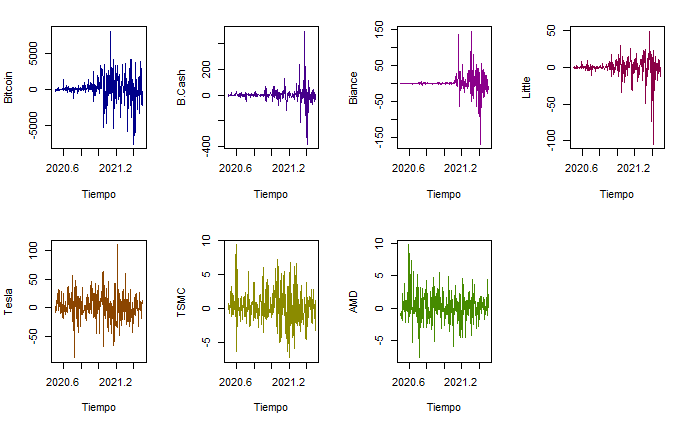

```r
plot(tiempo,d_est[,7], ylab = "AMD", xlab="Tiempo", type="l", col = "#468B00")
plot(tiempo,d_est[,8], ylab = "Qualcom", xlab="Tiempo", type="l", col = "#008B00")
```

### Test de causalidad de granger

Solo analizaremos la causalidad en los supuestos:

La cotización de Bitcoin causa al valor de las acciones de TESLA? La cotización de Bitcoin causa al valor de las acciones de AMD? La cotización de Bitcoin causa al valor de la cotización de Biance?

```r
# TESLA

for (i in 1:12){

  gt <- grangertest(tesla ~ bitcoin, order = i, data = d_est)

  if(gt[2,4]<0.05){

    cat("Bitcoin es causal de la otra variable apartir del rezago: ", i, "\n")
    break

  }
}
```

La cotización del Bitcoin no causa en el sentido de granger al valor de las acciones de Tesla en todos los 12 rezagos evaluados.

```r
for (i in 1:12){

  gt <- grangertest(amd ~ bitcoin, order = i, data = d_est)

  if(gt[2,4]<0.05){

    cat("Bitcoin es causal de la otra variable apartir del rezago: ", i, "\n")
    break

  }
}
```

La cotización del Bitcoin no causa en el sentido de granger al valor de las acciones de AMD en todos los 12 rezagos evaluados.

```r
for (i in 1:12){

  gt <- grangertest(biance ~ bitcoin, order = i, data = d_est)

  if(gt[2,4]<0.05){

    cat("Bitcoin es causal de la otra variable apartir del rezago: ", i, "\n")
    break

  }
}
```

```
Bitcoin es causal de la otra variable apartir del rezago:  5
```

La cotización del Bitcoin es causal en el sentido de granger la cotización del Biance apartir del rezago 5.

### Calculo orden del modelo VAR

```r
# Calculo orden del modelo VAR
VARselect(d_est, lag.max=12)
```

```
$selection
AIC(n)  HQ(n)  SC(n) FPE(n)
     1      1      1      1

$criteria
                  1            2            3            4            5            6            7            8            9           10
AIC(n) 4.400707e+01 4.404625e+01 4.419923e+01 4.436923e+01 4.441386e+01 4.447767e+01 4.459533e+01 4.468814e+01 4.477355e+01 4.475290e+01
HQ(n)  4.443440e+01 4.485342e+01 4.538625e+01 4.593610e+01 4.636057e+01 4.680423e+01 4.730173e+01 4.777439e+01 4.823964e+01 4.859883e+01
SC(n)  4.506703e+01 4.604839e+01 4.714356e+01 4.825575e+01 4.924256e+01 5.024856e+01 5.130840e+01 5.234339e+01 5.337099e+01 5.429252e+01
FPE(n) 1.294667e+19 1.348720e+19 1.578663e+19 1.887142e+19 2.000898e+19 2.177562e+19 2.522182e+19 2.878772e+19 3.301068e+19 3.452860e+19
                 11           12
AIC(n) 4.477068e+01 4.479916e+01
HQ(n)  4.899646e+01 4.940479e+01
SC(n)  5.525249e+01 5.622315e+01
FPE(n) 3.815546e+19 4.344171e+19
```

Todos los cirteios para seleccionar el numero de rezagos de nuestro modelo nos indican que el orden del modelo es 1.

### Proceso VAR mediante libreria vars

```r
var_s <- vars::VAR(d_est,p =1)
var_s
```

```
VAR Estimation Results:
=======================

Estimated coefficients for equation bitcoin:
============================================
Call:
bitcoin = bitcoin.l1 + bcash.l1 + biance.l1 + little.l1 + tesla.l1 + tsmc.l1 + amd.l1 + qualcom.l1 + const

bitcoin.l1   bcash.l1  biance.l1  little.l1   tesla.l1    tsmc.l1     amd.l1 qualcom.l1
 0.1376730 -8.9513292  1.1214217 -0.7249322 -5.3526682 69.0269762 -4.3936653  5.4108434
     const
93.2417459


Estimated coefficients for equation bcash:
==========================================
Call:
bcash = bitcoin.l1 + bcash.l1 + biance.l1 + little.l1 + tesla.l1 + tsmc.l1 + amd.l1 + qualcom.l1 + const

   bitcoin.l1      bcash.l1     biance.l1     little.l1      tesla.l1       tsmc.l1
-0.0008501984 -0.4429901672 -0.3489745677  1.7552969665 -0.0375967584 -0.9719491424
       amd.l1    qualcom.l1         const
 1.7120374134 -0.2150172854  1.8031122295


Estimated coefficients for equation biance:
===========================================
Call:
biance = bitcoin.l1 + bcash.l1 + biance.l1 + little.l1 + tesla.l1 + tsmc.l1 + amd.l1 + qualcom.l1 + const

  bitcoin.l1     bcash.l1    biance.l1    little.l1     tesla.l1      tsmc.l1
 0.003450837 -0.031880091 -0.106648441 -0.459925877 -0.080384646 -0.561819478
      amd.l1   qualcom.l1        const
 0.142090022  0.071720466  1.575993015


Estimated coefficients for equation little:
===========================================
Call:
little = bitcoin.l1 + bcash.l1 + biance.l1 + little.l1 + tesla.l1 + tsmc.l1 + amd.l1 + qualcom.l1 + const
```

[output cut: 34 more lines]

```
   bitcoin.l1      bcash.l1     biance.l1     little.l1      tesla.l1       tsmc.l1
-2.655458e-05  4.767296e-04 -6.119853e-03  3.048101e-03 -7.680535e-04 -8.018125e-02
       amd.l1    qualcom.l1         const
-3.941809e-02 -9.833567e-03  1.623467e-01


Estimated coefficients for equation qualcom:
============================================
Call:
qualcom = bitcoin.l1 + bcash.l1 + biance.l1 + little.l1 + tesla.l1 + tsmc.l1 + amd.l1 + qualcom.l1 + const

   bitcoin.l1      bcash.l1     biance.l1     little.l1      tesla.l1       tsmc.l1
 6.718783e-06  5.384158e-03 -1.140040e-02 -2.349591e-02 -1.718685e-03  2.950178e-02
       amd.l1    qualcom.l1         const
 5.785453e-02 -1.275325e-01  2.084142e-01
```

[output not shown]

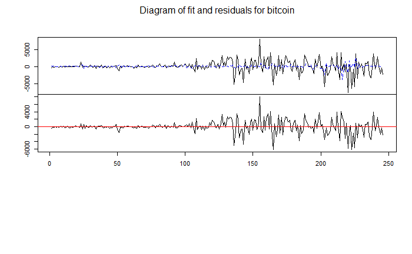

```r
plot(var_s)
```

### Proceso VAR mediante libreria MTS

```r
var_mts <- MTS::VAR(d_est, p =1)
```

```
Constant term:
Estimates:  93.24175 1.803112 1.575993 0.3631225 1.8885 0.3058461 0.1623467 0.2084142
Std.Error:  112.3765 3.911288 1.591688 0.8357832 1.558751 0.1632848 0.1506845 0.2100002
AR coefficient matrix
AR( 1 )-matrix
          [,1]      [,2]     [,3]     [,4]      [,5]    [,6]    [,7]     [,8]
[1,]  1.38e-01 -8.951329  1.12142 -0.72493 -5.352668 69.0270 -4.3937  5.41084
[2,] -8.50e-04 -0.442990 -0.34897  1.75530 -0.037597 -0.9719  1.7120 -0.21502
[3,]  3.45e-03 -0.031880 -0.10665 -0.45993 -0.080385 -0.5618  0.1421  0.07172
[4,]  1.14e-03 -0.075630 -0.02325  0.05618 -0.018298  0.4229 -0.0691  0.03361
[5,]  1.06e-03  0.018206  0.02296 -0.33172 -0.069239 -0.0446  0.2552 -0.45890
[6,]  1.49e-04  0.002626 -0.00705 -0.02539  0.000421 -0.2840  0.0823 -0.01269
[7,] -2.66e-05  0.000477 -0.00612  0.00305 -0.000768 -0.0802 -0.0394 -0.00983
[8,]  6.72e-06  0.005384 -0.01140 -0.02350 -0.001719  0.0295  0.0579 -0.12753
standard error
         [,1]    [,2]    [,3]    [,4]    [,5]    [,6]    [,7]    [,8]
[1,] 0.097440 3.26052 5.74212 18.5251 5.48028 55.3686 61.6173 43.3578
[2,] 0.003391 0.11348 0.19986  0.6448 0.19074  1.9271  2.1446  1.5091
[3,] 0.001380 0.04618 0.08133  0.2624 0.07762  0.7842  0.8727  0.6141
[4,] 0.000725 0.02425 0.04271  0.1378 0.04076  0.4118  0.4583  0.3225
[5,] 0.001352 0.04523 0.07965  0.2570 0.07602  0.7680  0.8547  0.6014
[6,] 0.000142 0.00474 0.00834  0.0269 0.00796  0.0805  0.0895  0.0630
[7,] 0.000131 0.00437 0.00770  0.0248 0.00735  0.0742  0.0826  0.0581
[8,] 0.000182 0.00609 0.01073  0.0346 0.01024  0.1035  0.1151  0.0810

Residuals cov-mtx:
             [,1]         [,2]          [,3]         [,4]        [,5]       [,6]
[1,] 2951083.5834 63089.984478 23043.2394538 1.578877e+04 11120.57359 970.741151
[2,]   63089.9845  3574.949235   791.7332240 6.436661e+02   203.98901  21.186975
[3,]   23043.2395   791.733224   592.0331847 1.907446e+02    69.72224   5.136735
[4,]   15788.7667   643.666125   190.7446000 1.632366e+02    61.10809   3.735362
[5,]   11120.5736   203.989013    69.7222404 6.110809e+01   567.78441  21.715101
[6,]     970.7412    21.186975     5.1367349 3.735362e+00    21.71510   6.230482
[7,]     369.1453     2.983253    -0.7487288 7.240247e-01    22.68697   3.023604
[8,]     970.2154    18.679205     3.4296646 3.369203e+00    31.05654   4.179756
            [,7]       [,8]
[1,] 369.1453097 970.215448
[2,]   2.9832528  18.679205
[3,]  -0.7487288   3.429665
[4,]   0.7240247   3.369203
[5,]  22.6869711  31.056539
[6,]   3.0236042   4.179756
[7,]   5.3060017   3.776972
[8,]   3.7769724  10.305515

det(SSE) =  5.184528e+18
AIC =  43.61043
BIC =  44.51974
HQ  =  43.97653
```

```r
summary(var_mts)
```

```
          Length Class  Mode
data      1976   -none- numeric
cnst         1   -none- logical
order        1   -none- numeric
coef        72   -none- numeric
aic          1   -none- numeric
bic          1   -none- numeric
hq           1   -none- numeric
residuals 1968   -none- numeric
secoef      72   -none- numeric
Sigma       64   -none- numeric
Phi         64   -none- numeric
Ph0          8   -none- numeric
fixed        0   -none- NULL
```

### Refinamiento del modelo MTS

```r
var_ref <- MTS::refVAR(var_mts,thres=0.8)
```

```
Constant term:
Estimates:  93.89131 0 1.599162 0 1.91657 0.309007 0.1600291 0.2154528
Std.Error:  111.4029 0 1.582997 0 1.537654 0.1618857 0.1487972 0.2076568
AR coefficient matrix
AR( 1 )-matrix
        [,1]     [,2]     [,3]    [,4]    [,5]   [,6]   [,7]    [,8]
[1,] 0.14220 -8.90368  0.00000  0.0000 -5.2980 70.278 0.0000  0.0000
[2,] 0.00000 -0.44746 -0.36745  1.6849  0.0000  0.000 0.0000  0.0000
[3,] 0.00347  0.00000 -0.11016 -0.5859 -0.0689 -0.534 0.0000  0.0000
[4,] 0.00113 -0.07087  0.00000  0.0000  0.0000  0.350 0.0000  0.0000
[5,] 0.00000  0.00000  0.00000 -0.1336 -0.0769  0.000 0.0000  0.0000
[6,] 0.00000  0.00000 -0.00612  0.0000  0.0000 -0.273 0.0775  0.0000
[7,] 0.00000  0.00000 -0.00539  0.0000  0.0000 -0.109 0.0000  0.0000
[8,] 0.00000  0.00567 -0.01129 -0.0245  0.0000  0.000 0.0000 -0.0993
standard error
        [,1]    [,2]    [,3]   [,4]   [,5]    [,6]   [,7]   [,8]
[1,] 0.08153 2.23933 0.00000 0.0000 5.0810 46.4321 0.0000 0.0000
[2,] 0.00000 0.11082 0.19338 0.5627 0.0000  0.0000 0.0000 0.0000
[3,] 0.00137 0.00000 0.08071 0.1891 0.0721  0.6608 0.0000 0.0000
[4,] 0.00059 0.01658 0.00000 0.0000 0.0000  0.3234 0.0000 0.0000
[5,] 0.00000 0.00000 0.00000 0.1179 0.0651  0.0000 0.0000 0.0000
[6,] 0.00000 0.00000 0.00641 0.0000 0.0000  0.0744 0.0819 0.0000
[7,] 0.00000 0.00000 0.00587 0.0000 0.0000  0.0577 0.0000 0.0000
[8,] 0.00000 0.00598 0.01042 0.0303 0.0000  0.0000 0.0000 0.0641

Residuals cov-mtx:
             [,1]        [,2]          [,3]         [,4]        [,5]       [,6]
[1,] 2951770.2645 63073.72408 23045.6439838 1.578071e+04 11113.33702 969.874090
[2,]   63073.7241  3589.90990   792.4764010 6.439123e+02   204.10054  21.028934
[3,]   23045.6440   792.47640   593.3493310 1.909002e+02    68.91995   5.034183
[4,]   15780.7109   643.91228   190.9001709 1.637734e+02    60.57889   3.705398
[5,]   11113.3370   204.10054    68.9199475 6.057889e+01   571.37521  22.009334
[6,]     969.8741    21.02893     5.0341834 3.705398e+00    22.00933   6.268546
[7,]     368.9440     2.79356    -0.7964328 7.565665e-01    22.66638   3.019215
[8,]     968.7075    18.88946     3.4583391 3.364496e+00    31.13077   4.180889
            [,7]       [,8]
[1,] 368.9439796 968.707541
[2,]   2.7935605  18.889459
[3,]  -0.7964328   3.458339
[4,]   0.7565665   3.364496
[5,]  22.6663792  31.130766
[6,]   3.0192153   4.180889
[7,]   5.3177906   3.772633
[8,]   3.7726330  10.327057

det(SSE) =  5.49531e+18
AIC =  43.36095
BIC =  43.73036
HQ  =  43.50968
```

### Prueba de autocorrelación serial

```r
seriala <- serial.test(var_s,lags.pt = 1, type = "PT.asymptotic")
seriala$serial
```

```
    Portmanteau Test (asymptotic)

data:  Residuals of VAR object var_s
Chi-squared = 7.8725, df = 0, p-value < 2.2e-16
```

Como p-value < 0.05 los residuales si están correlacionados

### Prueba de Normalidad de los residuales

```r
normalidad <- normality.test(var_s)
normalidad$jb.mul
```

```
$JB

    JB-Test (multivariate)

data:  Residuals of VAR object var_s
Chi-squared = 8589, df = 16, p-value < 2.2e-16


$Skewness

    Skewness only (multivariate)

data:  Residuals of VAR object var_s
Chi-squared = 277.06, df = 8, p-value < 2.2e-16


$Kurtosis

    Kurtosis only (multivariate)

data:  Residuals of VAR object var_s
Chi-squared = 8312, df = 8, p-value < 2.2e-16
```

Como p-value < 0.05 de la Kurtosis y el Skewness los residuales no se distribuyen de manera normal.

### Prueba de Homocedasticidad de la varianza de los residuales

```r
arch1 <- arch.test(var_s, lags.multi = 1)
arch1$arch.mul
```

```
    ARCH (multivariate)

data:  Residuals of VAR object var_s
Chi-squared = 2198.7, df = 1296, p-value < 2.2e-16
```

Como p-value < 0.05 la varianza de los residuales no es constante

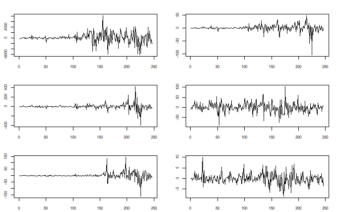

```r
MTSplot(var_mts$residuals[,1:6])
```